# MS1Match Tutorial

Ruibing Shi

30 June 2025

First, loading all the needed packages.

```r
library(xcms)
library(tibble)
library(dplyr)
library(tidyr)
library(tibble)
library(MS1Match)
```

## 1 Data Import and Peak Detection

### 1.1 Load demo data

We begin by preprocessing LC-MS data using the `xcms` package. The demo dataset `StM16`, included in the `MS1Match` package, will be used to illustrate the workflow.

```r
result_StM16 <- readRDS(system.file("extdata", "result_StM16.rds", package = "MS1Match"))
```

`result_StM16` is a list with four elements: `result_StM16[[1]]` is a `XCMSnExp` object from `XCMS`, `result_StM16[[2]]` is feature definition table, `result_StM16[[3]]` is the feature intensity table and `result_StM16[[4]]` is `XChromatograms` object where the information of the extracted ion chromatogram (EIC) is saved.

### 1.2 Run XCMS on Custom Files

Users can run `runXCMS()` to process their own `mzXML` or `mzML` files by specifying appropriate parameters from `xcms`.

```r
runXCMS_result <- runXCMS(files_dir,
                    peakwidth,
                    ppm,
                    snthresh,
                    mzdiff,
                    prefilter,
                    noise,
                    bw,
                    sample_name,
                    sample_group,
                    minFraction)
```

### 1.3 Prepare the Feature Table

We now create a feature table by combining the output from `result_StM16[[2]]` (feature definitions) and `result_StM16[[3]]` (intensity values). The table is then cleaned and prepared for downstream annotation.

In particular:

1. Convert the result to a data frame (**required**)
2. Rename the first column to `feature_name` (**required**)
3. Remove the `peakidx` column (**optional**)
4. Calculate a new column `intensity_mean` as the row-wise mean across samples (**required** if using multiple samples)
5. Sort the table by RT or m/z (**optional**)
6. Filter by retention time using `dplyr::filter()` (**optional**)  
   – In this example, we keep features with RT between 60 and 1200 seconds.

```r
result_StM16_FT_filtered <- processFeatureTable(result_StM16, sample_cols = "mzxml",rt_range = c(60,1200))
```

```
#>   feature_name    mzmed    mzmin    mzmax     rtmed     rtmin     rtmax npeaks PA14_Si11_10uM PA14_Si11_4uM PA14_Si11_8uM ms_level Pool-10um Si11 MS_GA2_01_50172.mzXML
#> 1       FT0001 73.53186 73.53181 73.53200  62.48560  62.20095  62.56080      5              1             2             2        1                             2621.479
#> 2       FT0002 77.03869 77.03863 77.03885 507.43372 507.17801 507.89575      9              3             3             3        1                            20545.509
#> 3       FT0003 77.03862 77.03856 77.03893 623.99783 623.63263 624.12665      4              1             0             3        1                             3288.009
#> 4       FT0004 79.02127 79.02116 79.02151  86.19352  85.94376  86.21645      8              3             2             3        1                           315362.580
#> 5       FT0005 79.02139 79.02126 79.02153 507.53258 507.23553 507.89575      6              3             0             3        1                             9164.350
#> 6       FT0006 80.02416 80.02407 80.02442  86.19698  85.68900  86.44751      8              3             2             3        1                            11695.948
#>   Pool-10um Si11 MS_GA2_01_50173.mzXML Pool-10um Si11 MS_GA2_01_50174.mzXML Pool-4umSi11_neu MS_GA3_01_50025.mzXML Pool-4umSi11_neu MS_GA3_01_50026.mzXML Pool-4umSi11_neu MS_GA3_01_50027.mzXML
#> 1                             2145.498                             2096.614                               2741.893                               2099.200                               2401.687
#> 2                            20888.043                            19884.383                              10866.668                               9942.735                              10991.598
#> 3                             3201.781                             3395.001                               1117.988                               1341.261                               1703.742
#> 4                           308719.214                           314205.141                             143318.925                             133845.154                             146105.055
#> 5                             8672.327                             8950.988                               1475.303                               1496.661                               1457.804
#> 6                            11029.087                             8652.228                               3915.212                               4312.724                               4293.655
#>   Pool-8umSi11_neu MS_GA4_01_50029.mzXML Pool-8umSi11_neu MS_GA4_01_50030.mzXML Pool-8umSi11_neu MS_GA4_01_50031.mzXML intensity_mean
#> 1                               2364.360                               2497.752                               1935.475       2322.662
#> 2                              20783.743                              22081.620                              21233.204      17468.611
#> 3                               3748.219                               3559.883                               3588.355       2771.582
#> 4                             290061.952                             297368.896                             304516.125     250389.227
#> 5                               6440.612                               6928.828                               7396.530       5775.934
#> 6                               9941.741                              10118.089                              11356.431       8368.346
```

## 2 Import Mass Spectral Library

To perform direct MS1 library matching, we first import the in-house spectral library `Si16.library`, which contains MS1 spectra for 16 pure reference compounds.

```r
Si16_library <- parse_library_parallel(file_path = system.file("extdata", "StM16_library", "Si16.library", package = "MS1Match"),
                                                    ionPolarity = "pos",spectrum_type ="MS1")
```

This returns a list-like object containing MS1 peak information per compound:

```r
Si16_library[[1]]
```

If you want to import an MS2 spectral library instead, you can specify spectrum_type = “MS2”:

```r
# Import MS2 library
Si16_MS2_library <- parse_library_parallel(file_path = system.file("extdata", "StM16_library", "Si11_library_MS2.library", package = "MS1Match"), ionPolarity = "pos",spectrum_type ="MS2")
```

## 3 Direct Matching to the MS1 Library

We now match the m/z values in the feature table to those of the primary ions (`[M+H]+`) in the MS1 spectral library. Once a primary ion is found, the corresponding peaks from the library are matched to neighboring features based on retention time (RT) proximity.

The feature table must be sorted by m/z; if not, `createDirectLibMatch()` will automatically sort it.

```r
DirectLibMatch_obj <- createDirectLibMatch(
  FT = result_StM16_FT_filtered,
  compounds_list = Si16_library,
  diff_mz_thr = 0.01,
  diff_rt_thr = 5,
  ppm = 10,
  ms_level = "MS1",
  polarity = "pos"
)
```

We can now annotate the feature table using the direct MS1 library match:

```r
direct_match_Stm16_res_MS1 <- libAnnotate(DirectLibMatch_obj)
```

```
#> Running MS1 library matching...
```

The result from `libAnnotate()` is a list containing matched annotations. You can convert it to a data frame for easier inspection:

```r
direct_match_Stm16_res_MS1[[1]]


# convert list to df
direct_match_Stm16_res_MS1_df <- do.call(rbind, lapply(direct_match_Stm16_res_MS1, function(x) {
  x[c("Compound_peak_mz_full", "Compound_peak_int_full")] <- NULL
  as.data.frame(x, stringsAsFactors = FALSE)
}))
```

```
#>   feature_name   Lib_group feature_mz feature_rt Compound_name Compound_rt Compound_peak_mz Compound_peak_int Ion_type Matched_peaks Match_peak_score Total_library_peaks Matched_features_to_peaks
#> 1       FT0823 Lib_group_1   231.1017   750.7205      Naproxen     750.693         115.0541                 7   [M+H]+           120        0.9677419                 124                    FT0126
#> 2       FT0823 Lib_group_1   231.1017   750.7205      Naproxen     750.693         128.0620                 2   [M+H]+           120        0.9677419                 124                    FT0212
#> 3       FT0823 Lib_group_1   231.1017   750.7205      Naproxen     750.693         141.0698                 7   [M+H]+           120        0.9677419                 124                    FT0307
#> 4       FT0823 Lib_group_1   231.1017   750.7205      Naproxen     750.693         142.0773                 4   [M+H]+           120        0.9677419                 124                    FT0318
#> 5       FT0823 Lib_group_1   231.1017   750.7205      Naproxen     750.693         144.0332                 1   [M+H]+           120        0.9677419                 124                    FT0326
#> 6       FT0823 Lib_group_1   231.1017   750.7205      Naproxen     750.693         147.5524                 1   [M+H]+           120        0.9677419                 124                    FT0365
#>   Matched_features_mz Matched_features_int
#> 1            115.0542            15562.582
#> 2            128.0620             4211.317
#> 3            141.0699            15858.906
#> 4            142.0773            10881.103
#> 5            144.0333             8678.839
#> 6            147.5525             9699.399
```

### 3.1 Visualizing MS1 Spectral Matches

`MS1Match` provides visualization tools to help inspect the quality of spectral matches between query features and reference library compounds using mirror. This function `plotMirrorSpectraSingle` creates a mirror plot using the matched feature peaks (on top) and reference library spectrum (on bottom). The cosine similarity score (inner and outer cosine from `Spectra`) and the match score are displayed in the plot. If no `output_dir` is provided, only the plot is shown. If `output_dir` is set, the plot will be saved as a PNG file instead.

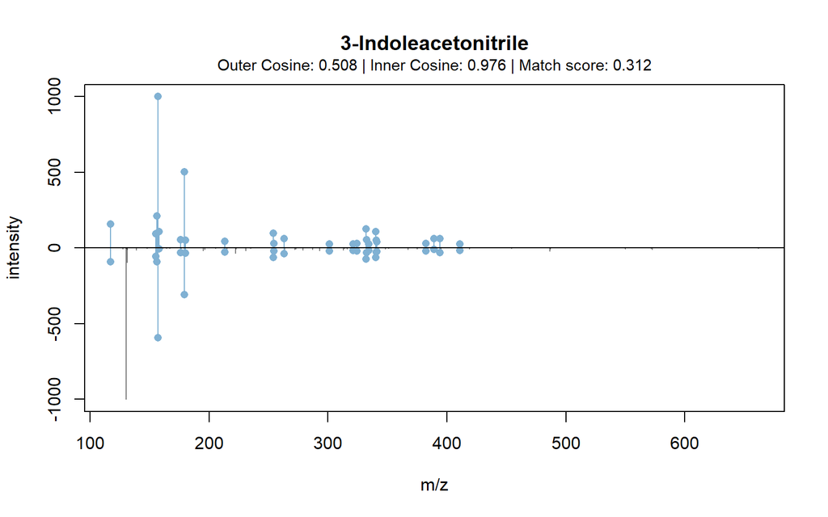

```r
plotMirrorSpectraSingle(object = DirectLibMatch_obj, match = direct_match_Stm16_res_MS1[[5]], output_dir = NULL)
```

### 3.2 Plot All Matches and Export

To generate and export mirror plots for all matched compounds at once:

```r
plotMirrorSpectra(object = DirectLibMatch_obj, matches = direct_match_Stm16_res_MS1, output_dir = "mirror_plots_Stm16_res_MS1")
```

## 4 Direct matching to the MS2 library

We can also use MS2 spectra to perform the direct matching and compare the results from MS1.

```r
DirectLibMatch_MS2_obj <- createDirectLibMatch(
  FT = result_StM16_FT_filtered,
  compounds_list = Si16_MS2_library,
  diff_mz_thr = 0.01,
  diff_rt_thr = 5,
  ppm = 10,
  ms_level = "MS2",
  polarity = "pos"
)
```

We can now annotate the feature table using the direct MS2 library match:

```r
direct_match_Stm16_res_MS2 <- libAnnotate(DirectLibMatch_MS2_obj)
```

```
#> Running MS2 library matching...
```

The result from libAnnotate() is a list containing matched annotations. You can convert it to a data frame for easier inspection:

```r
# convert list to df
direct_match_Stm16_res_MS2_df <- do.call(rbind, lapply(direct_match_Stm16_res_MS2, function(x) {
  x[c("Compound_peak_mz_full", "Compound_peak_int_full")] <- NULL
  as.data.frame(x, stringsAsFactors = FALSE)
}))
```

```
#>   feature_name   Lib_group feature_mz feature_rt Compound_name Compound_rt Compound_peak_mz Compound_peak_int Compound_peak_mz.1 Precursor_mz Matched_peaks Match_peak_score Total_library_peaks
#> 1       FT0823 Lib_group_1   231.1017   750.7205      Naproxen     751.772         115.0543                49           115.0543     231.0983            20        0.4761905                  42
#> 2       FT0823 Lib_group_1   231.1017   750.7205      Naproxen     751.772         128.0620                13           128.0620     231.0983            20        0.4761905                  42
#> 3       FT0823 Lib_group_1   231.1017   750.7205      Naproxen     751.772         141.0700                58           141.0700     231.0983            20        0.4761905                  42
#> 4       FT0823 Lib_group_1   231.1017   750.7205      Naproxen     751.772         142.0769                22           142.0769     231.0983            20        0.4761905                  42
#> 5       FT0823 Lib_group_1   231.1017   750.7205      Naproxen     751.772         152.0621                33           152.0621     231.0983            20        0.4761905                  42
#> 6       FT0823 Lib_group_1   231.1017   750.7205      Naproxen     751.772         153.0696                43           153.0696     231.0983            20        0.4761905                  42
#>   Matched_features_to_peaks Matched_features_mz Matched_features_int
#> 1                    FT0126            115.0542            15562.582
#> 2                    FT0212            128.0620             4211.317
#> 3                    FT0307            141.0699            15858.906
#> 4                    FT0318            142.0773            10881.103
#> 5                    FT0394            152.0621            13568.124
#> 6                    FT0398            153.0697            24698.067
```

Similarly, we plot the spectral mirror plot for the MS2 library matching result:

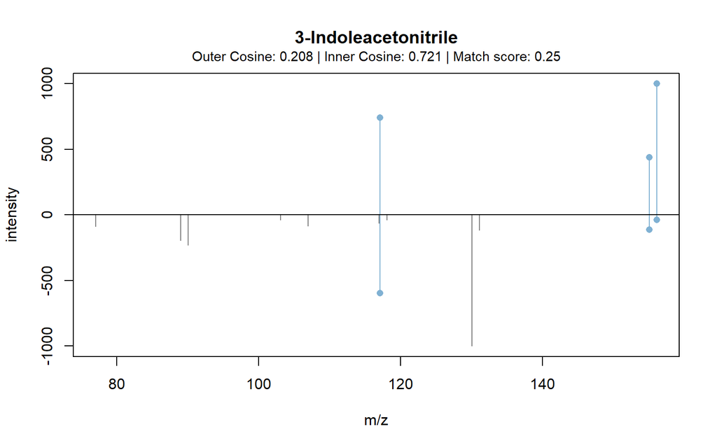

```r
plotMirrorSpectraSingle(object = DirectLibMatch_MS2_obj, match = direct_match_Stm16_res_MS2[[5]])
```

And export for all matched compound:

```r
plotMirrorSpectra(object = DirectLibMatch_MS2_obj, matches = direct_match_Stm16_res_MS2, output_dir = "mirror_plots_Stm16_res_MS2")
```

### 4.2 Compare MS1 and MS2 library matching results

To evaluate the annotation performance, we compare the number of features directly matched using the MS1 library versus the MS2 library.

```r
direct_match_res_MS1_df_subset <- direct_match_Stm16_res_MS1_df[,c("Compound_name", "Matched_peaks","Total_library_peaks")] %>% distinct()

direct_match_res_MS2_df_subset <- direct_match_Stm16_res_MS2_df[,c("Compound_name", "Matched_peaks","Total_library_peaks")] %>% distinct()



direct_match_res_MS1_MS2_join <- full_join(direct_match_res_MS1_df_subset, direct_match_res_MS2_df_subset, by = c("Compound_name"),
                                           suffix = c("_MS1", "_MS2"))
```

The result:

```
#>             Compound_name Matched_peaks_MS1 Total_library_peaks_MS1 Matched_peaks_MS2 Total_library_peaks_MS2
#> 1                Naproxen               120                     124                20                      42
#> 2   2-Methoxybenzoic acid                43                      50                11                      30
#> 3             Biochanin A                19                      50                 3                      48
#> 4      Trans-Ferulic acid                77                      84                14                      55
#> 5    3-Indoleacetonitrile                25                      80                 3                      12
#> 6 Indole-3-carboxaldehyde                30                      34                NA                      NA
```

## 5 Annotation of MS1-Matched Features

### 5.1 Import Supporting Tables

We first import the adduct and neutral loss tables:

```r
# Load adduct and neutral loss tables
adduct_table <- read.csv(system.file("extdata", "Adducts", "adducts.csv", package = "MS1Match"))

neutral_loss_table <- read.csv(system.file("extdata", "Neutral loss", "neutral loss database.csv", package = "MS1Match"), check.names = TRUE)
```

After identifying candidate features through direct MS1 library matching, we initialize a `PeakAnnotation` S4 object to annotate the features using adducts, neutral losses, and isotopic patterns

```r
# Create PeakAnnotation object
PeakAnnotation_obj <- createPeakAnnotation(compounds = Si16_library,
                                              FT =  result_StM16_FT_filtered,
                                              intensity =  result_StM16_FT_filtered$intensity_mean,
                                              neutral_loss_table = neutral_loss_table,
                                              adducts_df = adduct_table,
                                              PI_rt_threshold = 10 ,
                                              polarity = "positive")
```

Finally, we call the `annotate` to generate detailed annotations:

```r
StM16_annotate_res <- annotate(PeakAnnotation_obj)
```

```
#> Using RT-constrained annotation.
#> Sorting FT by m/z...
#> Features: 2580, Compounds: 16
#> Starting PI match...
#> Starting adduct match...
#> Adduct annotation completed.
#> Starting neutral loss match...
#> Starting isotope anotation...
#> Isotope anotation completed
#> Annotation completed.
```

The output is a list which includes primary ion, adduct, neutral loss, and isotope annotations for each feature.

```r
# check output
StM16_annotate_res[[1]]
```

```r
annotate_peaks_StM16_result_df <- plyr::ldply(StM16_annotate_res, data.frame, stringsAsFactors = FALSE)
```

```
#>   feature_name       mz        rt PI_match           adduct_match                                                                                                            NL_match iso_annotation
#> 1       FT0001 73.53186  62.48560             [M+2H]2+ 145.052764
#> 2       FT0003 77.03862 623.99783                                                                                                -C3H6 (FT0155); -C2H3NO (FT0268); -C8H15NO6 (FT1330)
#> 3       FT0002 77.03869 507.43372                                 -H2O (FT0036); -CO (FT0086); -CH2O (FT0103); -C2H2O2 (FT0271); -CH3NO2 (FT0299); -CN2O5 (FT0665); -C3H9O6P (FT0933)
#> 4       FT0004 79.02127  86.19352                                                                                  -CH3NO (FT0189); -CH3Cl (FT0219); -C3H5NO (FT0382); -CNO3 (FT0396)        [1][M]+
#> 5       FT0005 79.02139 507.53258                                                                                                                                   -C9H14O9 (FT1754)
#> 6       FT0006 80.02416  86.19698          [M+2H+Na]3+ 215.080710                                                 -CH4O (FT0111); -H3O4P/2 (FT0219); -C2H3NO (FT0294); -CNO3 (FT0408)      [1][M+1]+
```

## 6 Direct Target List Matching

In this section, we perform direct matching between feature table m/z values and target lists using known compounds from curated databases.

### 6.1 Import Target Lists

We first import the **PAMDB** target list for *Pseudomonas aeruginosa* metabolites:

```r
PA14_target_list <- PAMD_target_list_import(target_list_path = system.file("extdata", "Pseudomonas_target_list", "PaMetV2.csv", package = "MS1Match"))
```

```
#>                       Name     Formula RT MainPositiveAdduct MainNegativeAdduct                                                                                                                 InChI
#> 1       2-Ketobutyric acid      C4H6O3  0             [M+H]+             [M-H]-                                                                       InChI=1S/C4H6O3/c1-2-3(5)4(6)7/h2H2,1H3,(H,6,7)
#> 2             Deoxyuridine   C9H12N2O5  0             [M+H]+             [M-H]-  InChI=1S/C9H12N2O5/c12-4-6-5(13)3-8(16-6)11-2-1-7(14)10-9(11)15/h1-2,5-6,8,12-13H,3-4H2,(H,10,14,15)/t5-,6+,8+/m0/s1
#> 3            Deoxycytidine   C9H13N3O4  0             [M+H]+             [M-H]-  InChI=1S/C9H13N3O4/c10-7-1-2-12(9(15)11-7)8-3-5(14)6(4-13)16-8/h1-2,5-6,8,13-14H,3-4H2,(H2,10,11,15)/t5-,6+,8+/m0/s1
#> 4    a-Ketoisovaleric acid      C5H8O3  0             [M+H]+             [M-H]-                                                                    InChI=1S/C5H8O3/c1-3(2)4(6)5(7)8/h3H,1-2H3,(H,7,8)
#> 5 3-Hydroxyisobutyric acid      C4H8O3  0             [M+H]+             [M-H]-                                                                  InChI=1S/C4H8O3/c1-3(2-5)4(6)7/h3,5H,2H2,1H3,(H,6,7)
#> 6                   Biotin C10H16N2O3S  0             [M+H]+             [M-H]- InChI=1S/C10H16N2O3S/c13-8(14)4-2-1-3-7-9-6(5-16-7)11-10(15)12-9/h6-7,9H,1-5H2,(H,13,14)(H2,11,12,15)/t6-,7-,9-/m0/s1
#>   exactMass   [M+H]+   [M-H]-
#> 1  102.0317 103.0390 101.0244
#> 2  102.0317 229.0819 227.0673
#> 3  102.0317 228.0979 226.0833
#> 4  102.0317 117.0546 115.0401
#> 5  102.0317 105.0546 103.0401
#> 6  102.0317 245.0954 243.0809
```

The MS1Match package also includes a target list for human plasma metabolites (HMDB):

```r
hmdb_target_list <- HMDB_target_list_import(target_list_path = system.file("extdata", "hmdb", "hmdb_blood_detected.csv", package = "MS1Match"), IonPolarity = "pos")
```

### 6.2 Match Features to Target List

Matching is based on m/z of primary ions:

- [M+H]+ in positive ion mode
- [M-H]- in negative ion mode

```r
Stm16_PAMDB_PI_match <- PImatch_target (FT = result_StM16_FT_filtered,
                                   Comp_data = PA14_target_list,
                                   PIon = "[M+H]+",
                                   diff_mz_thr = 0.005,
                                   ppm = 10)
```

```r
# list to data frame

Stm16_PAMDB_PI_match_filtered_list <- Filter(function(x) length(x$Feature_name) > 0, Stm16_PAMDB_PI_match)

Stm16_PAMDB_PI_match_filtered_df <- do.call(rbind, lapply(Stm16_PAMDB_PI_match_filtered_list, as.data.frame)) %>%
  rename_with(~ paste0(.x, "_PAMDB"), .cols = -Feature_name)
```

```
#>   Feature_name Feature_mz_PAMDB            Comp_name_PAMDB PI_name_PAMDB  M_PAMDB
#> 1       FT0018         89.05990                    Acetoin        [M+H]+ 102.0317
#> 2       FT0050         98.98408        Inorganic phosphate        [M+H]+ 102.0317
#> 3       FT0051         98.98415        Inorganic phosphate        [M+H]+ 102.0317
#> 4       FT0052         98.98416        Inorganic phosphate        [M+H]+ 102.0317
#> 5       FT0060        102.05495        2-Aminobut-2-enoate        [M+H]+ 102.0317
#> 6       FT0083        104.07060 (S)-b-aminoisobutyric acid        [M+H]+ 102.0317
```

## 7 Join Annotation Results

To facilitate downstream analysis and export, we provide a wrapper function that merges the results from:

- MS1 library direct matching,
- Feature annotation (adducts, neutral losses, isotopes),
- External target list matching (e.g., PAMDB).

The result is a comprehensive annotated data frame.

```r
StM16_join_annotation_results <- join_annotation_results(direct_match_Stm16_res_MS1, StM16_annotate_res, Stm16_PAMDB_PI_match)
```

You can now export StM16_join_annotation_results or use it for further filtering, visualization, or reporting.

```
#> # A tibble: 6 × 25
#>   PI_feature_name Lib_group PI_feature_mz PI_feature_rt Compound_name Compound_rt Compound_peak_mz Compound_peak_int PI_Ion_type Matched_peaks Match_peak_score Total_library_peaks Matched_features_to_…¹
#>   <chr>           <chr>             <dbl>         <dbl> <chr>               <dbl>            <dbl>             <dbl> <chr>               <dbl>            <dbl>               <dbl> <chr>
#> 1 FT0823          Lib_grou…          231.          751. Naproxen             751.             115.                 7 [M+H]+                120            0.968                 124 FT0126
#> 2 FT0823          Lib_grou…          231.          751. Naproxen             751.             115.                 7 [M+H]+                120            0.968                 124 FT0126
#> 3 FT0823          Lib_grou…           NA            NA  <NA>                  NA              128.                 2 <NA>                   NA           NA                      NA FT0212
#> 4 FT0823          Lib_grou…           NA            NA  <NA>                  NA              141.                 7 <NA>                   NA           NA                      NA FT0307
#> 5 FT0823          Lib_grou…           NA            NA  <NA>                  NA              142.                 4 <NA>                   NA           NA                      NA FT0318
#> 6 FT0823          Lib_grou…           NA            NA  <NA>                  NA              144.                 1 <NA>                   NA           NA                      NA FT0326
#> # ℹ abbreviated name: ¹Matched_features_to_peaks
#> # ℹ 12 more variables: Matched_features_mz <dbl>, Matched_features_int <dbl>, mz <dbl>, rt <dbl>, PI_match <chr>, adduct_match <chr>, NL_match <chr>, iso_annotation <chr>, Feature_mz <dbl>,
#> #   Comp_name <chr>, PI_name <chr>, M <dbl>
```

And export it as a .csv file

```r
write.csv(StM16_join_annotation_results, "StM16_join_annotation_results.csv",row.names = FALSE)
```